# SRT411A0

Pol Govergun

January 29, 2017

This assignment is a short task to complete as an introduction to the R programming language, it has 14 todo examples that I have answered below. The assignment starts with two sections that describe how to download and install R and Rstudio, both resources are necessary to learning how to code with R. The first two sections also gives a small tutorial on how to use different directories in Rstudio and how to use libraries in Rstudio.

### 3 some first examples of R commands

#### 3.1 Calculator

*ToDo*: Computing the difference between 2014 and the year I started at this university (2015), divided by the difference between 2014 ad the year I was born (1997) and then muliply the result by 100.

```r
(2015 - 2014) / (2014 - 1997) * 100
```

```
## [1] 5.882353
```

#### 3.2 Workspace

*ToDo*: This todo is the same as the previous, except we add variables to some of the values we calculated.

```r
a <- 2015 - 2014
b <- 2014 - 1997
c <- 100

a / b * c
```

```
## [1] 5.882353
```

#### 3.3 Scalars, vectors and matrices

This section explains a bit about scalrs, vectors and matrices. A scalar is a single value like I assigned to ‘c’ in the pervious todo. A matrice is like a table with 2 dimensional values and lastly a vector is a one dimentional structure that concatenates any defined values.

#### 3.4 Functions

This section teaches us about how to create vectors and use functions, it gives a useful exmaple using the ‘rnorm’ function, which generates a random sample from a normal distribution, which you must specify, ex rnorm(10, mean=1.2). This command will generate 10 random numbers with a mean of 1.2. Furthermore, the resulting 10 numbers will automatically become a vector.

*Todo*: Compute the sum of the vector 4,5,8 and 11, by first creating a vector and using the sum function.

```r
d <- c(4,5,8,11)
sum(d)
```

```
## [1] 28
```

#### 3.5 Plots

This section teaches us about how to create a simple graph and plot 100 random numbers on this graph.

*ToDo*: Plot 100 normal random numbers.

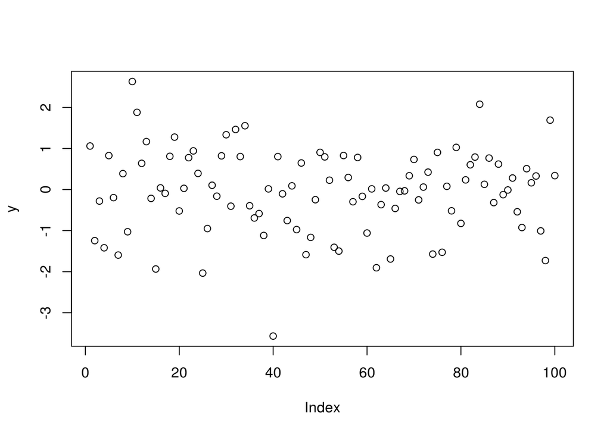

```r
y <- rnorm(100)
plot(y)
```

#### 4 Help and Documentation

This section teaches how a user can get help with any command in Rstudio, using the help(), function you can get a simple example and guidlines of how to use the function. Furthermore, for online web browsing help you can use the help.start() function.

*ToDo*: Find help for the sqrt function.

```r
help(sqrt)
```

#### 5 Scripts

This section describes the use of scripts in R as collection of multiple R commands stored in one file, usually with a .R extension. There are multiple ways to run your scripts, you can use the Rstudio windows or type CTRL + Shift + S or CTRL + ENTER.

*ToDo*: Make a file called firstscript.R containing code that generates 100 random numbers and plots them.

Firstly I typed CTRL + SHIFT + N, to create a new script file named firstscript.R and saved it in my documents. Then to run the script I typed ‘source(“firstscript.R”)’.

```r
source("firstscript.R")
```

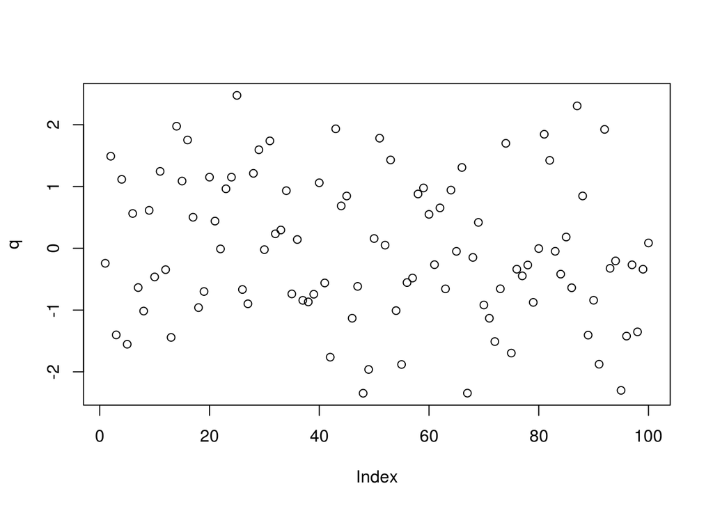

#### 6 Data Structures

In the 6.1 section, this guide describes vectors in more detail, it gives diffrent ways to create vectors, such as using the seq() function and displays different calculations that are common amongst vectors.

The 6.2 section teaches how matrices work and how to construct them.

*ToDo*: Put the numbers 31 to 60 in a vector named P and then in a matrix with 6 rows and 5 columns named Q.

```r
P <- seq(from=31, to=60)
P
```

```
##  [1] 31 32 33 34 35 36 37 38 39 40 41 42 43 44 45 46 47 48 49 50 51 52 53
## [24] 54 55 56 57 58 59 60
```

```r
Q <- matrix(data=P,ncol=5,nrow=6)
Q
```

```
##      [,1] [,2] [,3] [,4] [,5]
## [1,]   31   37   43   49   55
## [2,]   32   38   44   50   56
## [3,]   33   39   45   51   57
## [4,]   34   40   46   52   58
## [5,]   35   41   47   53   59
## [6,]   36   42   48   54   60
```

The next section 6.3, teaches about data frames and how to use them in combination with matrices and how to create and query their values.

```r
source("dataframescript.R")
```

[figure not shown]

The next line displays the code contained in the script dataframescript.R.

```r
x1 <- rnorm(100)
x2 <- rnorm(100)
x3 <- rnorm(100)
t = data.frame(a = x1, b = x1+x2, c = x1+x2+x3)
t
```

```
##                a            b           c
## 1    0.770392134 -0.339743098  0.65957109
## 2   -1.110377712 -1.060845676 -2.79531325
## 3    0.490015011  0.589883483 -0.99723044
## 4    1.025331043  2.932778465  3.93228618
## 5    0.489296905  0.901729309  1.04329897
## 6   -0.676940570 -0.769119077 -0.88840818
## 7    1.638401816  1.801218263  1.35435129
## 8   -0.992553770 -0.932682476 -1.76941591
## 9    0.941939015 -0.352023932 -0.46077883
## 10   0.394539689  1.217196041  0.63147463
## 11  -1.037215536 -0.813269968 -2.06779246
## 12  -1.679116349 -0.371225311  0.66172334
## 13  -0.504419393  1.170558320  1.38148697
## 14   0.188539691  1.684878708  0.35297712
```

[output cut: 86 more lines]

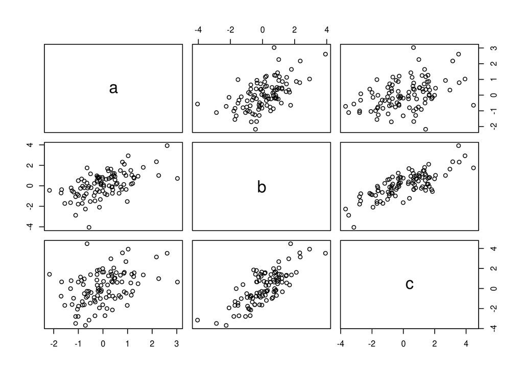

```r
plot(t)
```

The next section 6.4, describes how to create a list using the list() function, how to print a list, how to find out whats inside your list and how to apply the values in your list. A list is more useful than a matrice or data frame because you can add as many columns as you perfer with no order or specific length.

#### 7 Graphics

This section describes different ways to plot vectors and different graphical designs that can be made by R, anything from a histogram to a lined graph can be made.

*ToDo*: Add the lines above to your script from the previous todo and figure out what the rgb, lwd, pch and cex arguments mean.

```r
source("dataframescript.R")
```

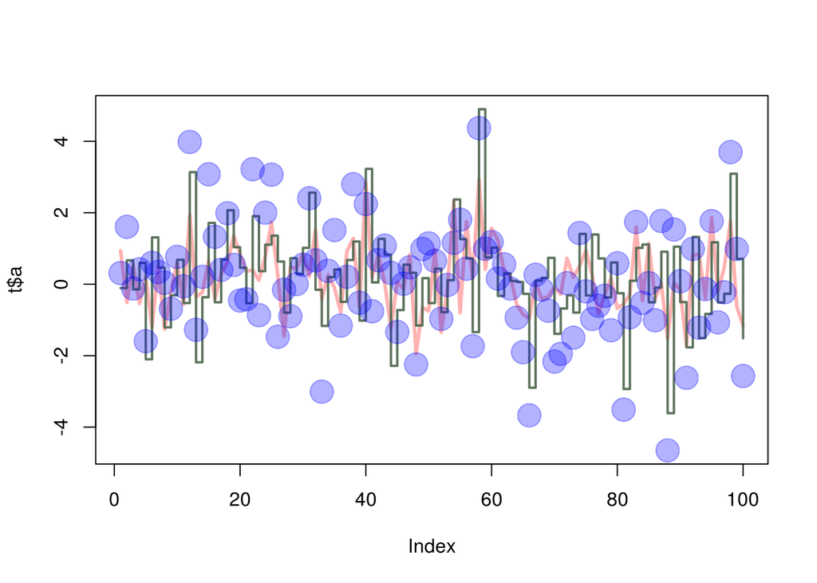

The code that was added is visible below

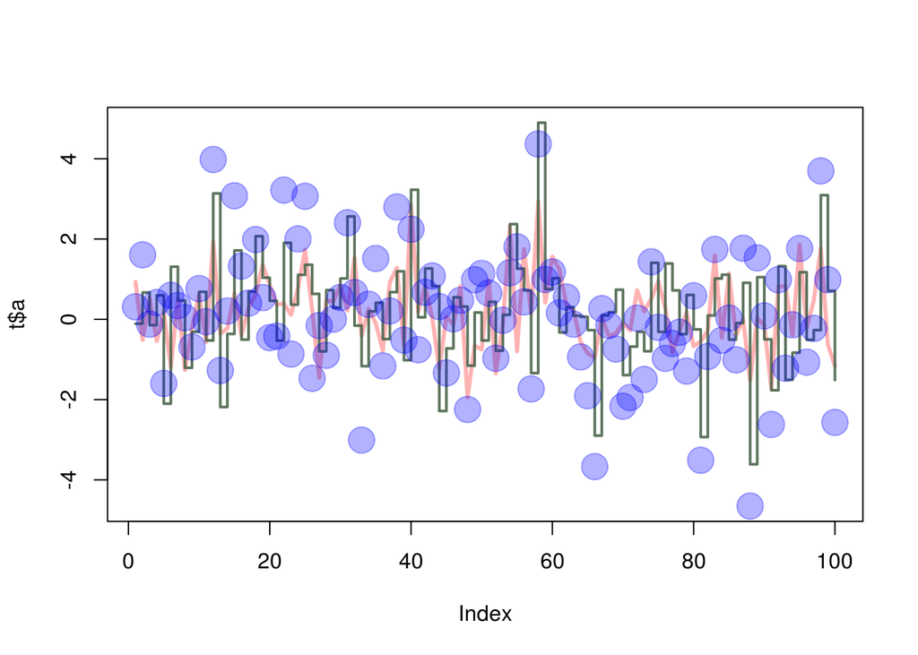

```r
plot(t$a, type="l", ylim=range(t), lwd=3, col=rgb(1,0,0,0.3))
lines(t$b, type="s", lwd=2, col=rgb(0.3,0.4,0.3,0.9))
points(t$c, pch=20, cex=4, col=rgb(0,0,1,0.3))
```

Essentially, the ‘cex’ argument is a number assigned to it that dictates the magnified level of text and symbols relative to the default. The ‘lwd’ argument specifies the line width, it must be a positive number. The ‘pch’ argument must be assigned an integer or a single character which is used as the default in plotting points. Lastly, the ‘rgb’ function is specifed when you want your graph to contain colors on the red, green and blue scale, you must also assign values of color to each column.